# 6장. 회귀분석

### 1절. 회귀분석 개념

#### 1. 회귀분석

: 원인(독립변수)이 결과(종속변수)에 미치는 영향 추정

#### 2. 선형회귀분석의 가정

- 독립변수와 종속변수 간의 선형성
- 오차의 등분산성
- 오차의 독립성
- 오차의 정규성

#### 3. 그래프를 활용한 선형회귀분석의 가정 검토

1. 선형성

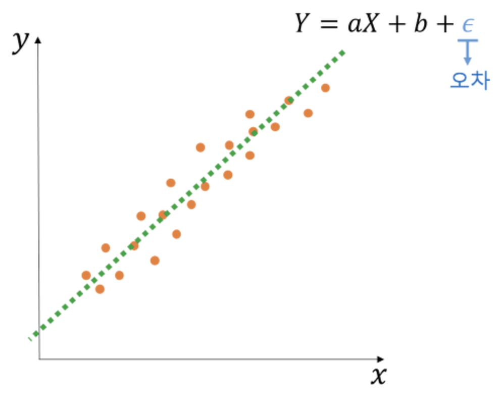

2. 등분산성

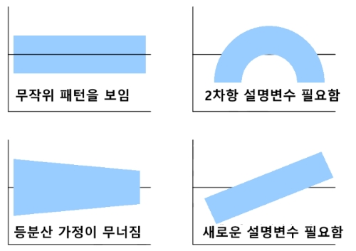

3. 정규성

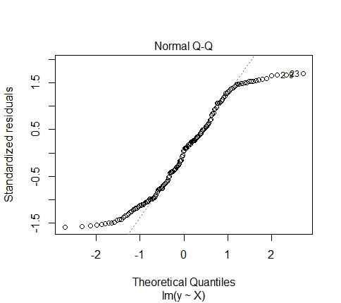

### 2절. 단순 선형회귀분석

#### 1. 단순 선형회귀분석(단변량 회귀분석)

$$Y_i = \beta_0 + \beta_1 x_i + \epsilon_i$$

#### 2. 회귀분석 시 검토사항

1. 모형 내의 회귀계수가 유의한가?
2. 모형은 데이터를 얼마나 설명할 수 있는가?
3. 회귀모형은 통계적으로 유의한가?
4. 모형의 데이터를 잘 적합하고 있는가?

#### 3. R을 이용한 단순선형회귀분석

- lm()

```r
library(MASS)
data("Cars93")
str(Cars93)
```

```
## 'data.frame':    93 obs. of  27 variables:
##  $ Manufacturer      : Factor w/ 32 levels "Acura","Audi",..: 1 1 2 2 3 4 4 4 4 5 ...
##  $ Model             : Factor w/ 93 levels "100","190E","240",..: 49 56 9 1 6 24 54 74 73 35 ...
##  $ Type              : Factor w/ 6 levels "Compact","Large",..: 4 3 1 3 3 3 2 2 3 2 ...
##  $ Min.Price         : num  12.9 29.2 25.9 30.8 23.7 14.2 19.9 22.6 26.3 33 ...
##  $ Price             : num  15.9 33.9 29.1 37.7 30 15.7 20.8 23.7 26.3 34.7 ...
##  $ Max.Price         : num  18.8 38.7 32.3 44.6 36.2 17.3 21.7 24.9 26.3 36.3 ...
##  $ MPG.city          : int  25 18 20 19 22 22 19 16 19 16 ...
##  $ MPG.highway       : int  31 25 26 26 30 31 28 25 27 25 ...
##  $ AirBags           : Factor w/ 3 levels "Driver & Passenger",..: 3 1 2 1 2 2 2 2 2 2 ...
##  $ DriveTrain        : Factor w/ 3 levels "4WD","Front",..: 2 2 2 2 3 2 2 3 2 2 ...
##  $ Cylinders         : Factor w/ 6 levels "3","4","5","6",..: 2 4 4 4 2 2 4 4 4 5 ...
##  $ EngineSize        : num  1.8 3.2 2.8 2.8 3.5 2.2 3.8 5.7 3.8 4.9 ...
##  $ Horsepower        : int  140 200 172 172 208 110 170 180 170 200 ...
##  $ RPM               : int  6300 5500 5500 5500 5700 5200 4800 4000 4800 4100 ...
##  $ Rev.per.mile      : int  2890 2335 2280 2535 2545 2565 1570 1320 1690 1510 ...
##  $ Man.trans.avail   : Factor w/ 2 levels "No","Yes": 2 2 2 2 2 1 1 1 1 1 ...
##  $ Fuel.tank.capacity: num  13.2 18 16.9 21.1 21.1 16.4 18 23 18.8 18 ...
##  $ Passengers        : int  5 5 5 6 4 6 6 6 5 6 ...
##  $ Length            : int  177 195 180 193 186 189 200 216 198 206 ...
##  $ Wheelbase         : int  102 115 102 106 109 105 111 116 108 114 ...
##  $ Width             : int  68 71 67 70 69 69 74 78 73 73 ...
##  $ Turn.circle       : int  37 38 37 37 39 41 42 45 41 43 ...
##  $ Rear.seat.room    : num  26.5 30 28 31 27 28 30.5 30.5 26.5 35 ...
##  $ Luggage.room      : int  11 15 14 17 13 16 17 21 14 18 ...
##  $ Weight            : int  2705 3560 3375 3405 3640 2880 3470 4105 3495 3620 ...
##  $ Origin            : Factor w/ 2 levels "USA","non-USA": 2 2 2 2 2 1 1 1 1 1 ...
##  $ Make              : Factor w/ 93 levels "Acura Integra",..: 1 2 4 3 5 6 7 9 8 10 ...
```

```r
Cars93_lm <- lm(Price~EngineSize, Cars93)
Cars93_lm
```

```
##
## Call:
## lm(formula = Price ~ EngineSize, data = Cars93)
##
## Coefficients:
## (Intercept)   EngineSize
##       4.669        5.563
```

```r
summary(Cars93_lm)
```

```
##
## Call:
## lm(formula = Price ~ EngineSize, data = Cars93)
##
## Residuals:
##     Min      1Q  Median      3Q     Max
## -13.684  -4.627  -1.795   2.592  39.429
##
## Coefficients:
##             Estimate Std. Error t value Pr(>|t|)
## (Intercept)   4.6692     2.2390   2.085   0.0398 *
## EngineSize    5.5629     0.7828   7.107 2.59e-10 ***
## ---
## Signif. codes:  0 '***' 0.001 '**' 0.01 '*' 0.05 '.' 0.1 ' ' 1
##
## Residual standard error: 7.789 on 91 degrees of freedom
## Multiple R-squared:  0.3569, Adjusted R-squared:  0.3499
## F-statistic: 50.51 on 1 and 91 DF,  p-value: 2.588e-10
```

1. 회귀모형의 포뮬러 : lm(y~x)
2. 회귀계수 : Coefficients
3. 모형의 설명력 : Adjusted R-squared
4. 모형의 통계적 유의성 : F-statistics

#### 4. R을 이용한 선형회귀모형 진단

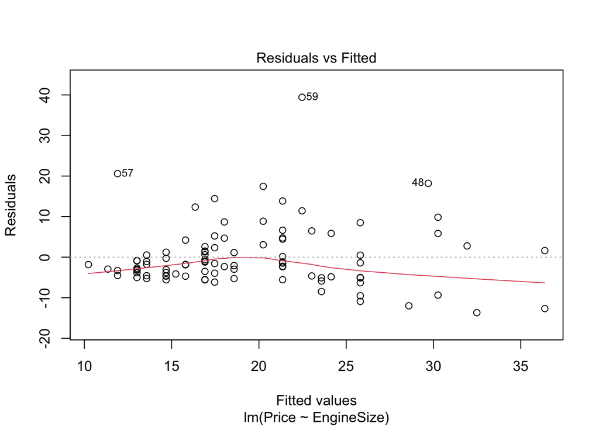

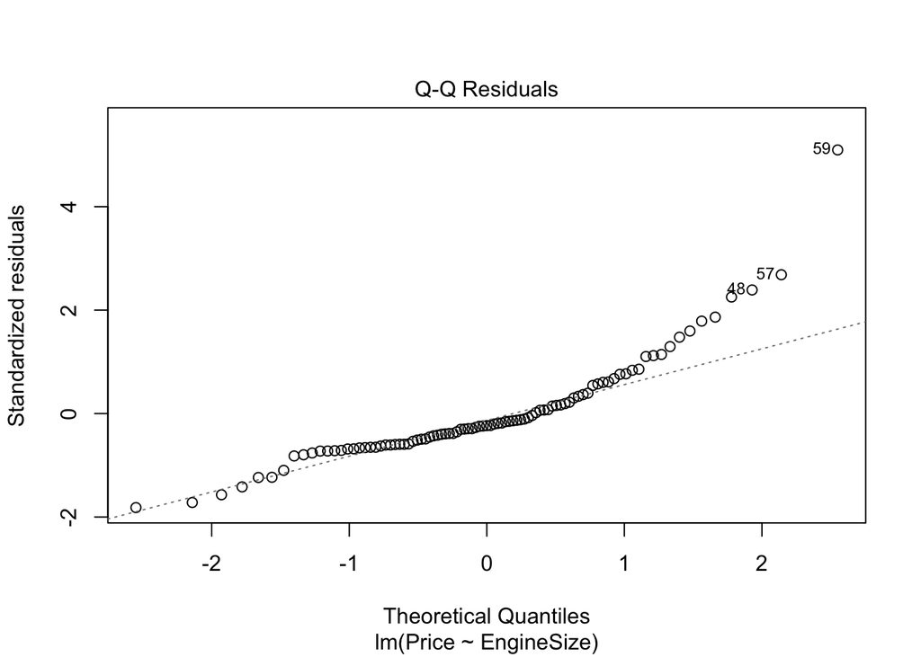

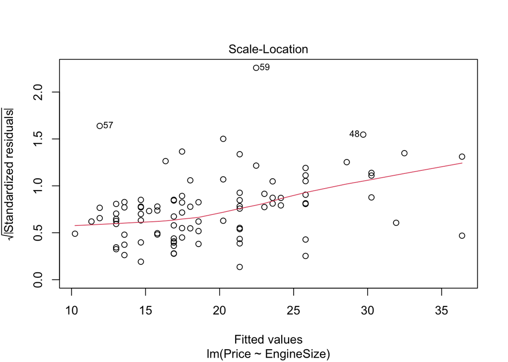

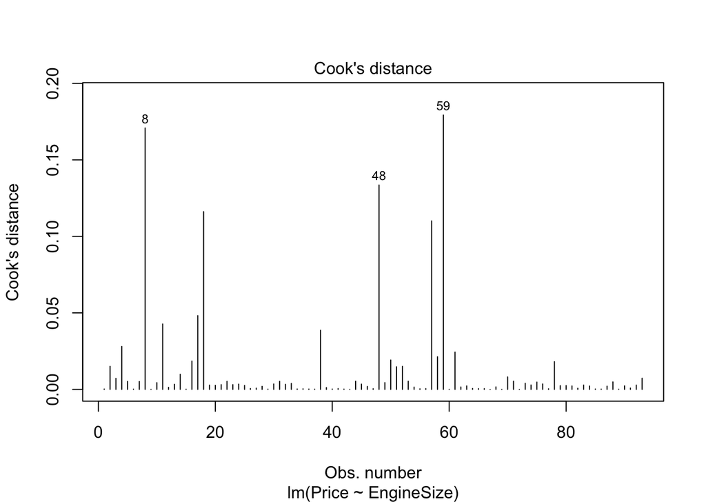

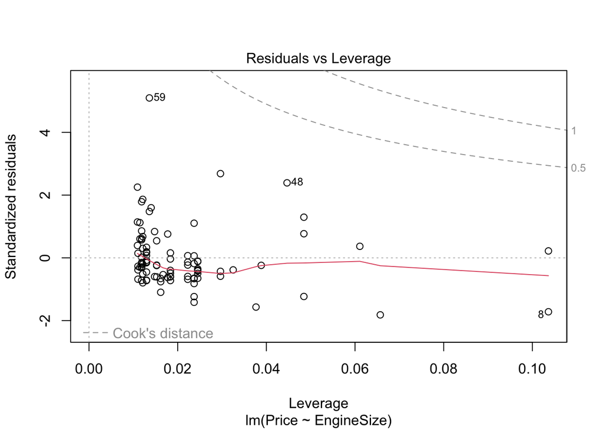

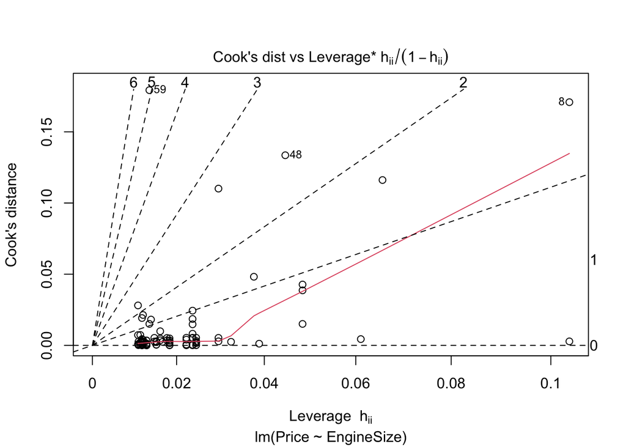

```r
plot(Cars93_lm, which = c(1:6))
```

#### 5. 선형회귀모형을 활용한 예측

- predict.lm

```r
Cars93_lm
```

```
##
## Call:
## lm(formula = Price ~ EngineSize, data = Cars93)
##
## Coefficients:
## (Intercept)   EngineSize
##       4.669        5.563
```

```r
set.seed(1234)
idx <- sample(1:nrow(Cars93),5)
idx
```

```
## [1] 28 80 22  9  5
```

```r
test <- Cars93[idx,]

# 점추정
predict.lm(Cars93_lm, test, interval = 'none')
```

```
##       28       80       22        9        5
## 21.35801 11.34472 23.02689 25.80836 24.13948
```

```r
# 회귀계수의 불확실성을 감안한 구간추정
predict.lm(Cars93_lm, test, interval = 'confidence')
```

```
##         fit       lwr      upr
## 28 21.35801 19.672604 23.04341
## 80 11.34472  8.555107 14.13433
## 22 23.02689 21.145364 24.90842
## 9  25.80836 23.426530 28.19019
## 5  24.13948 22.078345 26.20061
```

```r
# 회귀계수의 불확실성과 오차항을 감안한 구간추정
predict.lm(Cars93_lm, test, interval = 'prediction')
```

```
##         fit       lwr      upr
## 28 21.35801  5.795423 36.92060
## 80 11.34472 -4.375825 27.06526
## 22 23.02689  7.441846 38.61194
## 9  25.80836 10.155035 41.46169
## 5  24.13948  8.531732 39.74723
```

### 3절. 다중선형회귀분석

#### 1. 다중선형회귀분석(다변량 회귀분석)

$$Y = \beta_0 + \beta_1 x_1 + \beta_2 x_2 + \cdots + \beta_k x_k +\epsilon$$

#### 2. 다중선형회귀분석 시 검토사항

1. 데이터가 전제하는 가정을 만족시키는가?
2. 모형 내의 회귀계수가 유의한가?
3. 모형은 데이터를 얼마나 설명할 수 있는가?
4. 회귀모형은 통계적으로 유의한가?
5. 모형이 데이터를 잘 적합하고 있는가?
6. 다중공선성

#### 3. 더미변수(dummy variable)

- 범주형 변수 변환 - 기준이 되는 범주를 제외한 n-1개의 변수 생성
- lm함수의 범주형 변수 처리 - 자동 변환

```r
data("iris")
iris_lm <- lm(Petal.Length~., iris)
summary(iris_lm)
```

```
##
## Call:
## lm(formula = Petal.Length ~ ., data = iris)
##
## Residuals:
##      Min       1Q   Median       3Q      Max
## -0.78396 -0.15708  0.00193  0.14730  0.65418
##
## Coefficients:
##                   Estimate Std. Error t value Pr(>|t|)
## (Intercept)       -1.11099    0.26987  -4.117 6.45e-05 ***
## Sepal.Length       0.60801    0.05024  12.101  < 2e-16 ***
## Sepal.Width       -0.18052    0.08036  -2.246   0.0262 *
## Petal.Width        0.60222    0.12144   4.959 1.97e-06 ***
## Speciesversicolor  1.46337    0.17345   8.437 3.14e-14 ***
## Speciesvirginica   1.97422    0.24480   8.065 2.60e-13 ***
## ---
## Signif. codes:  0 '***' 0.001 '**' 0.01 '*' 0.05 '.' 0.1 ' ' 1
##
## Residual standard error: 0.2627 on 144 degrees of freedom
## Multiple R-squared:  0.9786, Adjusted R-squared:  0.9778
## F-statistic:  1317 on 5 and 144 DF,  p-value: < 2.2e-16
```

#### 4. R을 이용한 다중선형회귀분석

- lm()

```r
data("Cars93")
str(Cars93)
```

```
## 'data.frame':    93 obs. of  27 variables:
##  $ Manufacturer      : Factor w/ 32 levels "Acura","Audi",..: 1 1 2 2 3 4 4 4 4 5 ...
##  $ Model             : Factor w/ 93 levels "100","190E","240",..: 49 56 9 1 6 24 54 74 73 35 ...
##  $ Type              : Factor w/ 6 levels "Compact","Large",..: 4 3 1 3 3 3 2 2 3 2 ...
##  $ Min.Price         : num  12.9 29.2 25.9 30.8 23.7 14.2 19.9 22.6 26.3 33 ...
##  $ Price             : num  15.9 33.9 29.1 37.7 30 15.7 20.8 23.7 26.3 34.7 ...
##  $ Max.Price         : num  18.8 38.7 32.3 44.6 36.2 17.3 21.7 24.9 26.3 36.3 ...
##  $ MPG.city          : int  25 18 20 19 22 22 19 16 19 16 ...
##  $ MPG.highway       : int  31 25 26 26 30 31 28 25 27 25 ...
##  $ AirBags           : Factor w/ 3 levels "Driver & Passenger",..: 3 1 2 1 2 2 2 2 2 2 ...
##  $ DriveTrain        : Factor w/ 3 levels "4WD","Front",..: 2 2 2 2 3 2 2 3 2 2 ...
##  $ Cylinders         : Factor w/ 6 levels "3","4","5","6",..: 2 4 4 4 2 2 4 4 4 5 ...
##  $ EngineSize        : num  1.8 3.2 2.8 2.8 3.5 2.2 3.8 5.7 3.8 4.9 ...
##  $ Horsepower        : int  140 200 172 172 208 110 170 180 170 200 ...
##  $ RPM               : int  6300 5500 5500 5500 5700 5200 4800 4000 4800 4100 ...
##  $ Rev.per.mile      : int  2890 2335 2280 2535 2545 2565 1570 1320 1690 1510 ...
##  $ Man.trans.avail   : Factor w/ 2 levels "No","Yes": 2 2 2 2 2 1 1 1 1 1 ...
##  $ Fuel.tank.capacity: num  13.2 18 16.9 21.1 21.1 16.4 18 23 18.8 18 ...
##  $ Passengers        : int  5 5 5 6 4 6 6 6 5 6 ...
##  $ Length            : int  177 195 180 193 186 189 200 216 198 206 ...
##  $ Wheelbase         : int  102 115 102 106 109 105 111 116 108 114 ...
##  $ Width             : int  68 71 67 70 69 69 74 78 73 73 ...
##  $ Turn.circle       : int  37 38 37 37 39 41 42 45 41 43 ...
##  $ Rear.seat.room    : num  26.5 30 28 31 27 28 30.5 30.5 26.5 35 ...
##  $ Luggage.room      : int  11 15 14 17 13 16 17 21 14 18 ...
##  $ Weight            : int  2705 3560 3375 3405 3640 2880 3470 4105 3495 3620 ...
##  $ Origin            : Factor w/ 2 levels "USA","non-USA": 2 2 2 2 2 1 1 1 1 1 ...
##  $ Make              : Factor w/ 93 levels "Acura Integra",..: 1 2 4 3 5 6 7 9 8 10 ...
```

```r
Price_lm <- lm(Price ~ EngineSize+RPM+Weight, Cars93)
summary(Price_lm)
```

```
##
## Call:
## lm(formula = Price ~ EngineSize + RPM + Weight, data = Cars93)
##
## Residuals:
##     Min      1Q  Median      3Q     Max
## -10.511  -3.806  -0.300   1.447  35.255
##
## Coefficients:
##               Estimate Std. Error t value Pr(>|t|)
## (Intercept) -51.793292   9.106309  -5.688 1.62e-07 ***
## EngineSize    4.305387   1.324961   3.249  0.00163 **
## RPM           0.007096   0.001363   5.208 1.22e-06 ***
## Weight        0.007271   0.002157   3.372  0.00111 **
## ---
## Signif. codes:  0 '***' 0.001 '**' 0.01 '*' 0.05 '.' 0.1 ' ' 1
##
## Residual standard error: 6.504 on 89 degrees of freedom
## Multiple R-squared:  0.5614, Adjusted R-squared:  0.5467
## F-statistic: 37.98 on 3 and 89 DF,  p-value: 6.746e-16
```

1. 회귀모형의 포뮬러 : y ~ x1 + x2 + …
2. 회귀계수 : Coefficients
3. 모형의 설명력 : Adjusted R-squared
4. 모형의 통계적 유의성 : F-statistics

#### 5. 최적회귀방정식의 선택

- 단계적 변수 선택
  1. 전진 선택법
  2. 후진 제거법
  3. 단계적 방법
- 벌점화된 선택기준 - AIC or BIC 값이 최소가 되는 모형
  1. AIC
  2. BIC

#### 6. R을 이용한 변수선택법

- p-value 이용

```r
data("Cars93")

# 회귀모형
lm_a <- lm(Price~EngineSize+RPM+Width+Length, Cars93)
summary(lm_a)
```

```
##
## Call:
## lm(formula = Price ~ EngineSize + RPM + Width + Length, data = Cars93)
##
## Residuals:
##     Min      1Q  Median      3Q     Max
## -11.756  -4.239  -0.497   2.534  35.598
##
## Coefficients:
##               Estimate Std. Error t value Pr(>|t|)
## (Intercept) -20.151609  26.264641  -0.767    0.445
## EngineSize    8.380637   1.445736   5.797 1.04e-07 ***
## RPM           0.007139   0.001445   4.942 3.65e-06 ***
## Width        -0.654923   0.433125  -1.512    0.134
## Length        0.136676   0.088223   1.549    0.125
## ---
## Signif. codes:  0 '***' 0.001 '**' 0.01 '*' 0.05 '.' 0.1 ' ' 1
##
## Residual standard error: 6.823 on 88 degrees of freedom
## Multiple R-squared:  0.5227, Adjusted R-squared:  0.501
## F-statistic:  24.1 on 4 and 88 DF,  p-value: 1.762e-13
```

```r
# 유의확률이 가장 높은 변수 Width 제거 후 회귀모형
lm_b <- lm(Price~EngineSize+RPM+Length, Cars93)
summary(lm_b)
```

```
##
## Call:
## lm(formula = Price ~ EngineSize + RPM + Length, data = Cars93)
##
## Residuals:
##     Min      1Q  Median      3Q     Max
## -11.478  -4.269  -0.378   2.004  36.681
##
## Coefficients:
##               Estimate Std. Error t value Pr(>|t|)
## (Intercept) -52.601153  15.251540  -3.449 0.000862 ***
## EngineSize    7.110311   1.185062   6.000 4.18e-08 ***
## RPM           0.007492   0.001436   5.218 1.17e-06 ***
## Length        0.074112   0.078480   0.944 0.347549
## ---
## Signif. codes:  0 '***' 0.001 '**' 0.01 '*' 0.05 '.' 0.1 ' ' 1
##
## Residual standard error: 6.872 on 89 degrees of freedom
## Multiple R-squared:  0.5103, Adjusted R-squared:  0.4938
## F-statistic: 30.92 on 3 and 89 DF,  p-value: 8.699e-14
```

```r
# 유의확률이 가장 높은 변수 Length 제거 후 회귀모형
lm_c <- lm(Price~EngineSize+RPM, Cars93)
summary(lm_c)
```

```
##
## Call:
## lm(formula = Price ~ EngineSize + RPM, data = Cars93)
##
## Residuals:
##     Min      1Q  Median      3Q     Max
## -11.636  -4.085  -0.946   1.645  36.543
##
## Coefficients:
##               Estimate Std. Error t value Pr(>|t|)
## (Intercept) -40.977171   9.000017  -4.553 1.65e-05 ***
## EngineSize    7.913115   0.825140   9.590 2.03e-15 ***
## RPM           0.007457   0.001434   5.198 1.25e-06 ***
## ---
## Signif. codes:  0 '***' 0.001 '**' 0.01 '*' 0.05 '.' 0.1 ' ' 1
##
## Residual standard error: 6.868 on 90 degrees of freedom
## Multiple R-squared:  0.5054, Adjusted R-squared:  0.4944
## F-statistic: 45.99 on 2 and 90 DF,  p-value: 1.74e-14
```

- step(object, scope, direction, k)

```r
# 후진제거법
lm_result <- lm(Price~EngineSize+Horsepower+RPM+Width+Length, Cars93)
step(lm_result, direction = 'backward')
```

```
## Start:  AIC=327.45
## Price ~ EngineSize + Horsepower + RPM + Width + Length
##
##              Df Sum of Sq    RSS    AIC
## - EngineSize  1      0.05 2764.2 325.45
## <none>                    2764.2 327.45
## - RPM         1     65.53 2829.7 327.62
## - Length      1    285.29 3049.4 334.58
## - Width       1    414.88 3179.0 338.45
## - Horsepower  1   1332.75 4096.9 362.04
##
## Step:  AIC=325.45
## Price ~ Horsepower + RPM + Width + Length
##
##              Df Sum of Sq    RSS    AIC
## <none>                    2764.2 325.45
## - RPM         1    120.58 2884.8 327.42
## - Length      1    314.61 3078.8 333.47
## - Width       1    425.45 3189.7 336.76
## - Horsepower  1   2897.11 5661.3 390.12
```

```
##
## Call:
## lm(formula = Price ~ Horsepower + RPM + Width + Length, data = Cars93)
##
## Coefficients:
## (Intercept)   Horsepower          RPM        Width       Length
##   62.001064     0.174981    -0.002843    -1.347265     0.222816
```